# Introduction to Bayesian inference

Ladislas Nalborczyk  
Univ. Grenoble Alpes, CNRS, LPNC (France) • Ghent University (Belgium)

### Probabilistic interpretations

What is the probability…

- Of obtaining an even number when rolling a (non biased) die ?
- That I learn something new during this talk ?

Do these two questions refer to the exact same meaning of the concept of *probability* ?

### Probability axioms

A probability is a numerical value assigned to an event \( A \), this event being a possibility of an ensemble \( \Omega \) (the ensemble of all possible events). Probabilities conform to the following axioms (the third axiom is only valid for mutually exclusive events):

- **Non-negativity.** \( P(A_{i}) \geq 0 \)
- **Normalisation.** \( P(\Omega) = 1 \)
- **Additivity.** \( P(A_{1}\cup A_{2}\cup \ldots) = \sum_{i=1}^{+\infty}P(A_{i}) \)

*Kolmogorov, A.N. (1933). “Foundations of the Theory of Probability”.*

### Classic (or theoretical) interpretation

\[ P(even)=\frac{number\ of\ favorable\ cases}{number\ of\ possible\ cases}=\frac{3}{6}=\frac{1}{2} \]

Problem: this definition only applies to situations in which there is a finite ensemble of equiprobables possible events…

> What is the probability of raining tomorrow ?

> \[ P(rain)=\frac{rain}{ \{ rain,\ non-rain \} }=\frac{1}{2}?? \]

### Frequentist (or empirical) interprétation

\[ P(x)=\lim_{n_{t} \to \infty}\frac{n_{x}}{n_{t}} \]

Where \( n_{x} \) is the number of events \( x \) and \( n_{t} \) the total number of trials. The **frequentist** interpretation postulates that, **in the long run** (when the number of trial approaches infinity), the relative frequency will eventually converge to what we call *probability*.

Consequence: the concept or *probability* only applies to collectives, and not to singular events.

### Frequentist (or empirical) interprétation

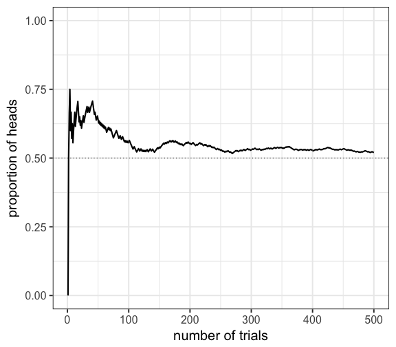

```r
library(tidyverse)

sample(c(0, 1), 500, replace = TRUE) %>%
        data.frame %>%
        mutate(x = seq_along(.), y = cumsum(.) / seq_along(.) ) %>%
        ggplot(aes(x = x, y = y), log = "y") +
        geom_line(lwd = 1) +
        geom_hline(yintercept = 0.5, lty = 3) +
        xlab("number of trials") +
        ylab("proportion of heads") +
        ylim(0, 1) +
        theme_bw(base_size = 20)
```

### Problems...

- What is the reference class ? *What is the probability of me living until 80 years ?*
- What about non-repetable events ? *What is the probability of me learning something new during this course ?*
- How many trials are sufficient to obtain a good approximation of the *probability* ? A finite class of events of size \( n \) can only produce relative frequencies of certain resolution/preciseness \( 1/n \).

### Propensity interpretation

Les propriétés fréquentistes (i.e., à long terme) des objets (e.g., une pièce) seraient provoquées par des propriétés physiques intrinsèques aux objets. Par exemple, une pièce biaisée va engendrer une fréquence relative (et donc une probabilité) biaisée en raison de ses propriétés physiques. Pour les propensionnistes, les probabilités représentent ces caractéristiques intrinsèques, ces **propensions** à générer certaines fréquences relatives, et non les fréquences relatives en elles-mêmes.

Conséquence: ces propriétés sont les propriétés d'événements individuels… et non de séquences ! L'interpétation propensionniste nous permet donc de parler de la probabilité d'événements uniques.

### Logical interpretation

Il y a 10 étudiants dans cette salle

9 portent un t-shirt vert

1 porte un t-shirt rouge

Une personne est tirée au sort…

> Conclusion 1: l'étudiant tiré au sort porte un t-shirt ✔

> Conclusion 2: l'étudiant tiré au sort porte un t-shirt vert ✗

> Conclusion 3: l'étudiant tiré au sort porte un t-shirt rouge ✗

### Interprétation logique

L'interprétation logique du concept de probabilité essaye de généraliser la logique (vrai / faux) au monde probabiliste. La probabilité représente donc le *degré de support logique* qu'une conclusion peut avoir, relativement à un ensemble de prémices (Keynes, 1921; Carnap, 1950).

Conséquence: toute probabilité est **conditionnelle**.

### Interprétation bayésienne

**La probabilité est une mesure du degré d'incertitude**. Un événement *certain* aura donc une probabilité de 1 et un événement *impossible* aura une probabilité de 0.

Pour parler de probabilités, dans ce cadre, nous n'avons donc plus besoin de nous référer à la limite d'occurrence d'un événement (fréquence).

> “So to assign equal probabilities to two events is not in any way an assertion that they must occur equally often in any random experiment […], it is only a formal way of saying I don’t know.” - Jaynes (1986)

### Interprétations probabilistes

- Interprétation classique ou théorique (Laplace, Bernouilli, Leibniz)
- **Interprétation fréquentiste ou empirique** (Venn, Reichenbach, von Mises)
- Interprétation propensionniste (Popper, Miller)
- Interprétation logique (Keynes, Carnap)
- **Interprétation subjective ou bayésienne** (Jeffreys, de Finetti, Savage)

*[Plus de détails ici](http://plato.stanford.edu/entries/probability-interpret/)*…

### Interprétations probabilistes - résumé

> **Probabilité epistémique (subjective)**
> - toute probabilité est conditionnelle à de l'information disponible (e.g., prémices ou données)
> - la probabilité comme moyen de quantifier l'incertitude
> - probabilité logique, probabilité bayésienne

> **Probabilité physique (objective)**
> - les probabilités dépendent d'un état du monde, de caractéristiques physiques, elles sont indépendantes de l'information disponible (ou de l'incertitude)
> - probabilité classique, probabilité fréquentiste

[figure not shown]

### Aparté - Vous avez dit "hasard" ?

Une suite de nombres au hasard…

```
[1] 79 27 98 28 42
```

`runif, rnorm, rbinom...`

```r
RNGkind()[1] # default random number generator
```

```
[1] "Mersenne-Twister"
```

### Mersenne-Twister

Inventé par Makoto Matsumoto et Takuji Nishimura en 1997, le [Mersenne Twister](https://en.wikipedia.org/wiki/Mersenne_Twister) est un générateur de nombres pseudo-aléatoires (PRNG). L'algorithme Mersenne-Twister est le PRNG par défaut en Python, Ruby, R, PHP, Matlab…

[figure not shown]

### Hasard déterministe

\[ Y_{i} \sim \mathrm{Uniform}(10,100) \]

```r
set.seed(666)
as.integer(runif(5, 10, 100) )
```

```
[1] 79 27 98 28 42
```

Si je connais la *graine* d'origine (i.e., le “départ” de l'algorithme) et le fonctionnement précis de l'algorithme, je peux prédire les nombres qui vont être générés. Il sera alors difficile de soutenir que ces nombres auront été générés au “hasard”…

```
[1] 79 27 98 28 42 76
```

```
[1] 79 27 98 28 42 76 98
```

### Le langage de l'incertain

“Le hasard est un concept indiquant l'aspect aléatoire des choses, des événements ou encore des décisions, signalant ainsi l'impossibilité de prévoir avec certitude un fait quelconque. Ainsi, pour éclairer le sens du mot, il peut-être dit que le hasard est synonyme d'« imprévisibilité », ou « imprédictibilité »” ([Wikipédia](https://fr.wikipedia.org/wiki/Hasard)).

> “Ce que nous appelons hasard n’est et ne peut être que la cause ignorée d’un effet connu.” – Voltaire

> “Le hasard, ce sont les lois que nous ne connaissons pas.” – Émile Borel

Le hasard apparait donc comme un **état subjectif d'indétermination des causes**. Pour parler de l'incertain (pour quantifier l'incertitude), on utilise les probabilités comme langage.

> “Randomness is a proxy for lack of knowledge” – Richard McElreath

### Un peu de logique

[figure not shown]

### Un peu de logique

**Example 1**

- Si un suspect ment, il transpire.
- (On observe que) ce suspect transpire.
- Par conséquent, ce suspect ment.

**Example 2**

- Si le suspect ment, il va présenter une réaction galvanique cutanée (parce qu'il va se mettre à transpirer).
- (On observe que) Le suspect ne présente pas de réaction galvanique cutanée.
- Par conséquent, le suspect ne ment pas.

**Example 3**

- Tous les menteurs transpirent.
- (On observe que) Ce suspect ne transpire pas.
- Par conséquent, ce suspect n'est pas un menteur.

### Inférences invalides

- *affirmation du conséquent*: \( \dfrac{A \Rightarrow B, \ B}{A} \)
- Si il a plu, alors le sol est mouillé (A implique B). Le sol est mouillé (B). Donc il a plu (A).
- *négation de l'antécédent*: \( \dfrac{A \Rightarrow B, \ \neg A}{\neg B} \)
- Si il a plu, alors le sol est mouillé (A implique B). Il n'a pas plus (non A). Donc le sol n'est pas mouillé (non B).

### Inférences valides

- *modus ponens*: \( \dfrac{A \Rightarrow B, \ A}{B} \)
- Si on est lundi, alors John ira au travail (A implique B). On est lundi (A). Donc John ira au travail (B).
- *modus tollens*: \( \dfrac{A \Rightarrow B, \ \neg B}{\neg A} \)
- Si mon chien détecte un intru, alors il aboie (A implique B). Mon chien n'a pas aboyé (non B). Donc il n'a pas détecté d'intrus (non A).

### Logique, fréquentisme et raisonnement probabiliste

Le *modus tollens* est un des raisonnements logiques les plus importants et les plus performants. Dans le cadre de l'inférence statistique, il s'applique parfaitement au cas suivant: “Si \( H_{0} \) est vraie, alors \( x \) ne devrait pas se produire. On observe \( x \). Alors \( H_{0} \) est fausse”.

Mais nous avons le plus souvent affaire à des hypothèses “continues”, probabilistes.

L'inférence fréquentiste (fishérienne) est elle aussi probabiliste, de la forme “Si \( H_{0} \) est vraie, alors \( x \) est peu probable. On observe \( x \). Alors \( H_{0} \) est peu probable.”

Or cet argument est invalide, le *modus tollens* ne s'applique pas au monde probabiliste (e.g., Pollard & Richardson, 1987; Rouder, Morey, Verhagen, Province, & Wagenmakers, 2016).

Par exemple: *si un individu est un homme, alors il est peu probable qu'il soit pape. Francois est pape. François n'est donc certainement pas un homme…*

### L'échec de la falsification

Forme logique d'un test expérimental d'une théorie \( T \) (from Meehl, 1990)

\[ (T \land A_{t} \land C_{p} \land A_{i} \land C_{n}) \to (O1 \supset O2) \]

Où \( A_{t} \) est une conjonction d'hypothèses auxiliaires, \( C_{p} \) est le *ceteribus paribus* (“all other things being equal”), \( A_{i} \) est une théorie concernant les instruments, et \( C_{n} \) un énoncé à propos des conditions particulières de cette expérience (*particulars*).

Observer \( (O1 \land \lnot O2) \) n'est pas suffisant pour falsifier \( T \), car cela revient à dire que toute la partie gauche est fausse. Or, dire qu'une conjonction est fausse revient à énoncer une disjunction des conjoints (i.e., \( (T \lor A_{t} \lor C_{p} \lor A_{i} \lor C_{n}) \)).

En résumé, on a falsifié une combinaison de tous les élements de la partie gauche, mais observer \( (O1 \land \lnot O2) \), ne falsifie pas (le coeur) de la théorie \( T \) (see also Lakatos, 1970).

### L'échec de la falsification

*Poppérisme naïf*: la science progresse par falsification logique, donc la statistique devrait viser la falsification. Mais…

- les hypothèses (théoriques) ne sont pas les modèles (hypothèses statistiques)

> “Models are devices that connect theories to data. A model is an instanciation of a theory as a set of probabilistic statements” – (Rouder et al., 2016)
- nos hypothèses sont souvent probabilistes
- erreur de mesure
- la falsification concerne le problème de la démarcation, pas celui de la méthode
- la science est une technologie sociale, la falsification est **consensuelle**, et non pas logique

### Notre stratégie

Besoin d'un cadre pour développer des modèles cohérents. Nos outils:

- *Bayesian data analysis*, utiliser les probabilités pour décrire l'incertitude, et étendre la logique au monde probabiliste
- *multilevel modeling*, des modèles à multiples niveaux d'incertitude
- approche par comparaison de modèle, au lieu d'essayer de falsifier un *null model*, comparer des modèles intéressants (AIC, WAIC)

### Comparaison de modèles

On s'intéresse au lien entre deux variables aléatoires continues, \( x \) et \( y \).

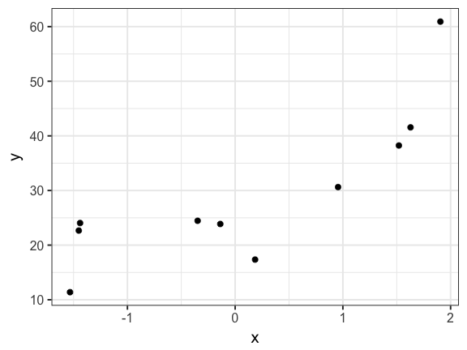

### Comparaison de modèles

L'hypothèse de modélisation la plus simple est de postuler une relation linéaire.

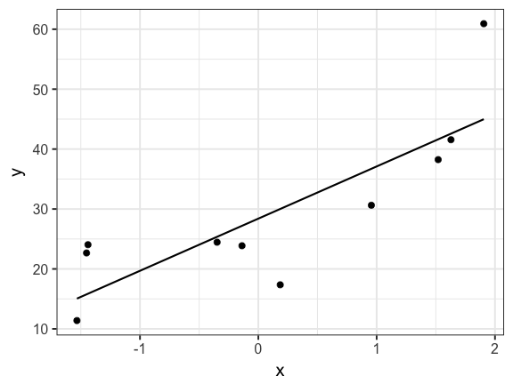

### Comparaison de modèles

Cette description peut-être *améliorée* pour mieux prendre en compte les données qui s'écartent de la prédiction linéaire.

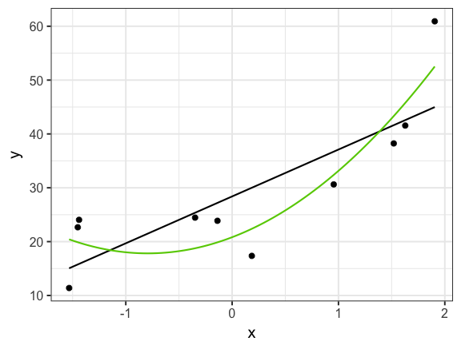

### Comparaison de modèles

Un ensemble de \( N \) points peut être *exhaustivement* (sans erreur) décrit par une fonction polynomiale d'ordre \( N-1 \). Augmenter la complexité du modèle améliore donc la précision de notre description des données mais réduit la généralisabilité de ses prédictions (*bias-variance tradeoff*).

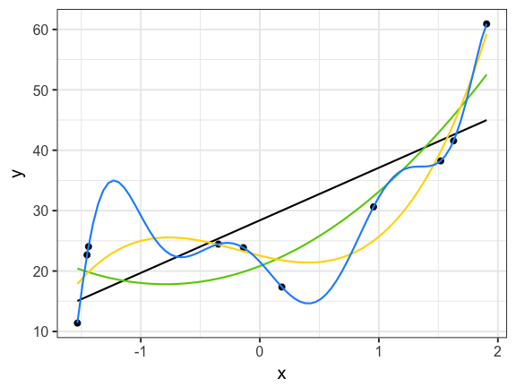

Nous avons besoin d'outils qui prennent en compte le rapport *qualité de la description* / *complexité*, c'est à dire la **parcimonie** des modèles (AIC, WAIC).

### Inférence bayésienne

Dans ce cadre, pour chaque problème, nous allons suivre 3 étapes:

- Construire le modèle (l'histoire des données): *likelihood* + *prior*
- Mettre à jour grâce aux données (*updating*), calculer la probabilité *a posteriori*
- Evaluer le modèle, *fit*, sensibilité, résumer les résultats, ré-ajuster

> “Bayesian inference is really just counting and comparing of possibilities […] in order to make good inference about what actually happened, it helps to consider everything that could have happened.” – McElreath (2015).

### Exercice - Problème du sac de billes

Imaginons que nous disposions d'un sac, contenant 4 billes. Ces billes peuvent être soit blanches, soit bleues. Nous savons qu'il y a précisémment 4 billes, mais nous ne connaissons pas le nombre de billes blanches, ou bleues.

Nous savons cependant qu'il existe cinq possibilités (que nous considérerons comme nos *hypothèses*):

> ⚪ ⚪ ⚪ ⚪

> 🔵 ⚪ ⚪ ⚪

> 🔵 🔵 ⚪ ⚪

> 🔵 🔵 🔵 ⚪

> 🔵 🔵 🔵 🔵

### Exercice - Problème du sac de billes

Le but est de déterminer quelle combinaison serait la plus probable, **sachant certaines observations**. Imaginons que l'on tire trois billes à la suite, avec remise, et que l'on obtienne la séquence suivante:

🔵 ⚪ 🔵

Cette séquence représente nos données. A partir de là, quelle **inférence** peut-on faire sur le contenu du sac ? En d'autres termes, que peut-on dire de la probabilité de chaque hypothèse ?

> ⚪ ⚪ ⚪ ⚪

> 🔵 ⚪ ⚪ ⚪

> 🔵 🔵 ⚪ ⚪

> 🔵 🔵 🔵 ⚪

> 🔵 🔵 🔵 🔵

### Enumérer les possibilités

hypothèse: 🔵 ⚪ ⚪ ⚪ données: 🔵

### Enumérer les possibilités

hypothèse: 🔵 ⚪ ⚪ ⚪ données: 🔵 ⚪

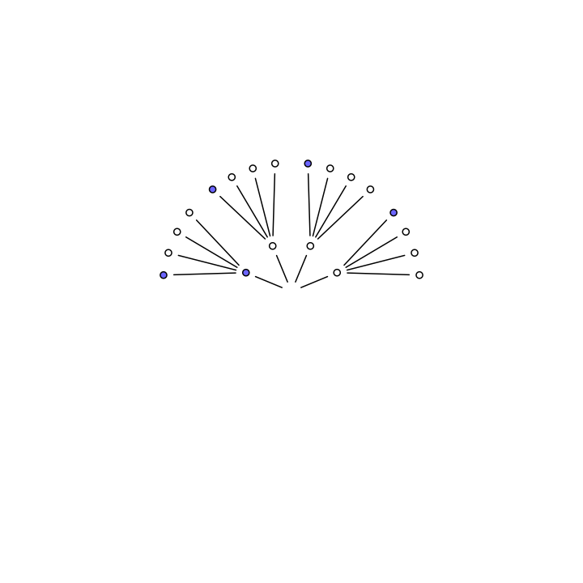

### Enumérer les possibilités

hypothèse: 🔵 ⚪ ⚪ ⚪ données: 🔵 ⚪ 🔵

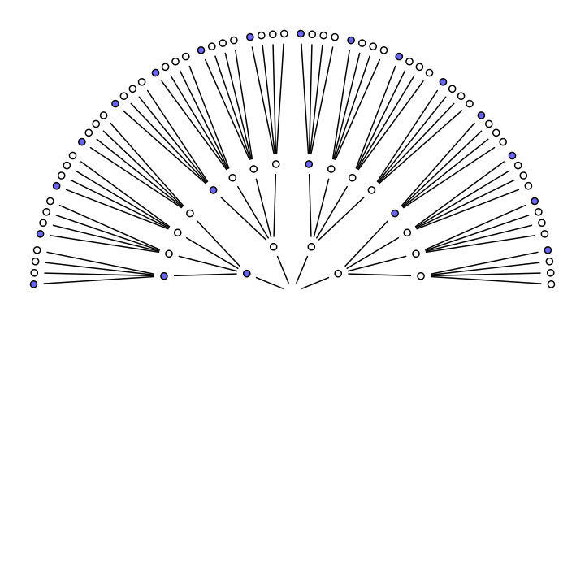

### Enumérer les possibilités

hypothèse: 🔵 ⚪ ⚪ ⚪ données: 🔵 ⚪ 🔵

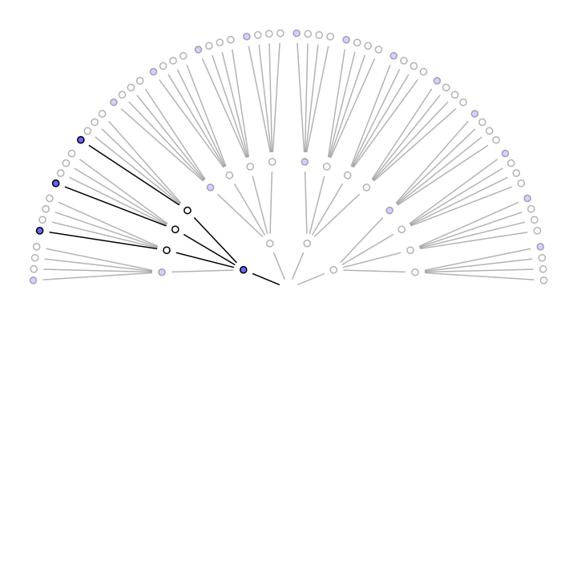

### Enumérer les possibilités

Sous cette hypothèse, \( 3 \) chemins (sur \( 4^{3}=64 \)) conduisent au résultat obtenu. Qu'en est-il des autres hypothèses?

⚪ ⚪ ⚪ 🔵 ⚪ 🔵 🔵 🔵 ⚪ ⚪ 🔵 🔵

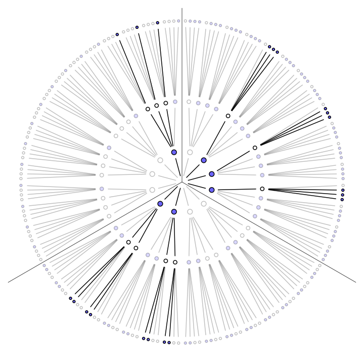

### Comparer les hypothèses

🔵 🔵 🔵 ⚪

Au vu des données, cette hypothèse est la plus *probable* car c'est l'hypothèse qui maximise le nombre de manières possibles d'obtenir les données obtenues.

| Hypothèse | Façons d'obtenir les données |
| --- | --- |
| ⚪ ⚪ ⚪ ⚪ | 0 x 4 x 0 = 0 |
| 🔵 ⚪ ⚪ ⚪ | 1 x 3 x 1 = 3 |
| 🔵 🔵 ⚪ ⚪ | 2 x 2 x 2 = 8 |
| 🔵 🔵 🔵 ⚪ | 3 x 1 x 3 = 9 |
| 🔵 🔵 🔵 🔵 | 4 x 0 x 4 = 0 |

### Accumulation d'évidence

Dans le cas précédent, nous avons considéré que toutes les hypothèses étaient équiprobables a priori (*principe d'indifférence*). Cependant, on pourrait avoir de l'information a priori, provenant de nos connaissances (des particularités des sacs de billes par exemple) ou de données antérieures.

Imaginons que nous tirions une nouvelle bille du sac, comment incorporer cette nouvelle donnée ?

### Accumulation d'évidence

Il suffit d'appliquer la même stratégie que précédemment, et de mettre à jour le dernier compte en le multipliant par ces nouvelles données. *Yesterday's posterior is today's prior* (Lindley, 2000).

| Hypothèse | Façons de produire 🔵 | Compte précédent | Nouveau compte |
| --- | --- | --- | --- |
| ⚪ ⚪ ⚪ ⚪ | 0 | 0 | 0 x 0 = 0 |
| 🔵 ⚪ ⚪ ⚪ | 1 | 3 | 3 x 1 = 3 |
| 🔵 🔵 ⚪ ⚪ | 2 | 8 | 8 x 2 = 16 |
| 🔵 🔵 🔵 ⚪ | 3 | 9 | 9 x 3 = 27 |
| 🔵 🔵 🔵 🔵 | 4 | 0 | 0 x 4 = 0 |

### Incorporer un prior

Supposons maintenant qu'un employé de l'usine de fabrication des billes nous dise que les billes bleues sont rares… Cet employé nous dit que pour chaque sac contenant 3 billes bleues, ils fabriquent deux sacs en contenant seulement deux, et trois sacs en contenant seulement une. Il nous apprend également que tous les sacs contiennent au moins une bille bleue et une bille blanche.

| Hypothèse | Compte précédent | Prior usine | Nouveau compte |
| --- | --- | --- | --- |
| ⚪ ⚪ ⚪ ⚪ | 0 | 0 | 0 x 0 = 0 |
| 🔵 ⚪ ⚪ ⚪ | 3 | 3 | 3 x 3 = 9 |
| 🔵 🔵 ⚪ ⚪ | 16 | 2 | 16 x 2 = 32 |
| 🔵 🔵 🔵 ⚪ | 27 | 1 | 27 x 1 = 27 |
| 🔵 🔵 🔵 🔵 | 0 | 0 | 0 x 0 = 0 |

### Des énumérations aux probabilités

La plausiblité d'une hypothèse après avoir observé certaines données est proportionnelle au nombre de façons qu'a cette hypothèse de produire les données observées, multiplié par sa plausibilité a priori.

\[ p(hypothesis|data)\propto p(data|hypothesis) \times p(hypothesis) \]

Pour passer des *plausibilités* aux *probabilités*, il suffit de standardiser ces plausibilités pour que la somme des plausibilités de toutes les hypothèses possibles soit égale à \( 1 \).

\[ p(hypothesis|data) = \frac{p(data|hypothesis) \times p(hypothesis)}{sum\ of\ products} \]

### Des énumérations aux probabilités

Définissons \( p \) comme la proportion de billes bleues.

| Hypothèse | p | Manières de produire les données | Plausibilité |
| --- | --- | --- | --- |
| ⚪ ⚪ ⚪ ⚪ | 0 | 0 | 0 |
| 🔵 ⚪ ⚪ ⚪ | 0.25 | 3 | 0.15 |
| 🔵 🔵 ⚪ ⚪ | 0.5 | 8 | 0.40 |
| 🔵 🔵 🔵 ⚪ | 0.75 | 9 | 0.45 |
| 🔵 🔵 🔵 🔵 | 1 | 0 | 0 |

```r
ways <- c(0, 3, 8, 9, 0)
ways / sum(ways)
```

```
[1] 0.00 0.15 0.40 0.45 0.00
```

### Notations, terminologie

- \( \theta \) un paramètre ou vecteur de paramètres (e.g., la proportion de billes bleues)
- \( \color{orangered}{p(x\vert \theta)} \) la distribution de probabilité conditionnelle des données \( x \) sachant le paramètre \( \theta \). Une fois que la valeur de \( x \) est connue, est vue comme la fonction de vraissemblance (*likelihood*) du paramètre \( \theta \)
- \( \color{steelblue}{p(\theta)} \) la distribution de probabilité a priori de \( \theta \)
- \( \color{purple}{p(\theta \vert x)} \) la distribution de probabilité a posteriori de \( \theta \) (sachant \( x \))
- \( \color{green}{p(x)} \) la distribution de probabilité marginale de \( x \) (sur \( \theta \))

\[ \color{purple}{p(\theta \vert x)} = \dfrac{\color{orangered}{p(x\vert \theta)} \color{steelblue}{p(\theta)}}{\color{green}{p(x)}} = \dfrac{\color{orangered}{p(x\vert \theta)} \color{steelblue}{p(\theta)}}{\color{green}{\sum\limits_{\theta}p(x|\theta)p(\theta)}} = \dfrac{\color{orangered}{p(x\vert \theta)} \color{steelblue}{p(\theta)}}{\color{green}{\int\limits_{\theta}p(x|\theta)p(\theta)\mathrm{d}x}} \propto \color{orangered}{p(x\vert \theta)} \color{steelblue}{p(\theta)} \]

### Loi de probabilité, cas discret

Une fonction de masse (*probability mass function*, ou *PMF*) est une fonction qui attribue une probabilité à chaque valeur d'une variable aléatoire. Exemple de la distribution binomiale pour une pièce non biaisée (\( \theta=0.5 \)).

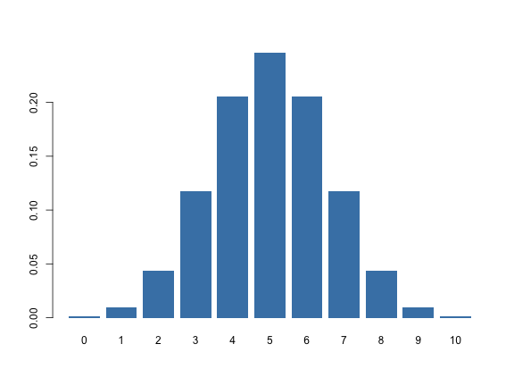

```r
dbinom(x = 0:10, size = 10, prob = 0.5) %>% sum
```

```
[1] 1
```

### Cas continu

Une densité de probabilité (*probability density function*, ou *PDF*), est une fonction qui permet de représenter une loi de probabilité sous forme d'intégrales.

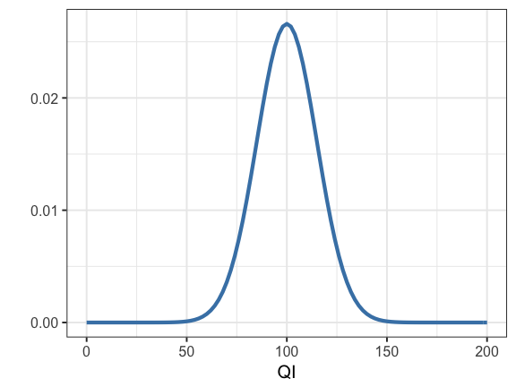

```r
integrate(dnorm, -Inf, Inf, mean = 100, sd = 15)
```

```
1 with absolute error < 1.3e-06
```

### Aparté, qu'est-ce qu'une intégrale ?

Une intégrale correspond à la **surface** (aire géométrique) délimitée par la représentation graphique d'une fonction, *l'aire sous la courbe*. Une distribution est dite **impropre** si son intégrale n'est pas égale à un nombre fini (e.g., \( + \infty \)), et **normalisée** si son intégrale est égale à 1.

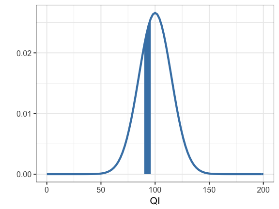

### Aparté, qu'est-ce qu'une intégrale ?

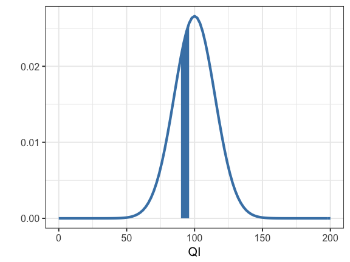

L'intégrale de \( f(x) \) sur l'intervalle [90 ; 96] vaut: \( \int_{90}^{96} f(x) \ \mathrm{d}x = 0.142 \).

```r
integrate(dnorm, 90, 96, mean = 100, sd = 15)
```

```
0.1423704 with absolute error < 1.6e-15
```

### Probabilité conjointe

```r
library(magrittr)

data(HairEyeColor) # data adapted from Snee (1974)

cont <- apply(HairEyeColor, c(1, 2), sum) %>% t
cont <- round(cont / sum(cont), 2)
cont
```

```
       Hair
Eye     Black Brown  Red Blond
  Brown  0.11  0.20 0.04  0.01
  Blue   0.03  0.14 0.03  0.16
  Hazel  0.03  0.09 0.02  0.02
  Green  0.01  0.05 0.02  0.03
```

Dans chaque cellule, on trouve la **probabilité conjointe** d'avoir telle couleur de cheveux **ET** telle couleur d'yeux, qui s'écrit \( p(c,y)=p(y,c) \).

### Probabilité marginale

```r
cont2 <- cont %>% as.data.frame %>% mutate(marginal_eye = rowSums(cont) )
rownames(cont2) <- row.names(cont)
cont2
```

```
      Black Brown  Red Blond marginal_eye
Brown  0.11  0.20 0.04  0.01         0.36
Blue   0.03  0.14 0.03  0.16         0.36
Hazel  0.03  0.09 0.02  0.02         0.16
Green  0.01  0.05 0.02  0.03         0.11
```

On peut aussi s'intéresser à la probabilité d'avoir des yeux bleus, de manière générale. Il s'agit de la probabilité **marginale** de l'événement *yeux bleus*, qui s'obtient par la somme de toutes les probabilités jointes impliquant l'évenement *yeux bleus*. Elle s'écrit \( p(y)=\sum\limits_{c}p(y|c)p(c) \).

### Probabilité marginale

```r
cont3 <- rbind(cont2, colSums(cont2) )
rownames(cont3) <- c(row.names(cont2), "marginal_hair")
cont3
```

```
              Black Brown  Red Blond marginal_eye
Brown          0.11  0.20 0.04  0.01         0.36
Blue           0.03  0.14 0.03  0.16         0.36
Hazel          0.03  0.09 0.02  0.02         0.16
Green          0.01  0.05 0.02  0.03         0.11
marginal_hair  0.18  0.48 0.11  0.22         0.99
```

On peut bien entendu aussi s'intéresser aux probabilités des couleurs de cheveux, de manière générale. Elle s'écrit \( p(c)=\sum\limits_{y}p(c|y)p(y) \).

### Probabilité conditionnelle

```
     Black Brown  Red Blond marginal_eye
Blue  0.03  0.14 0.03  0.16         0.36
```

On pourrait aussi s'intéresser à la probabilité qu'une personne ait les cheveux blonds, **sachant** qu'elle a les yeux bleus. Il s'agit d'une probabilité **conditionnelle**, et s'écrit \( p(c|y) \). Cette probabilité conditionnelle peut se ré-écrire: \( p(c|y)= \frac{p(c,y)}{p(y)} \).

```r
cont3["Blue","Blond"] / cont3["Blue","marginal_eye"]
```

```
     Blue
0.4444444
```

### Probabilité conditionnelle, règle du produit

On remarque dans le cas précédent que \( p(blonds|bleus) \) **n'est pas nécessairement égal** à \( p(bleus|blonds) \).

Autre exemple: la probabilité de mourir sachant qu'on a été attaqué par un requin n'est pas la même que la probabilité d'avoir été attaqué par un requin, sachant qu'on est mort.

De la même manière, \( p(data|H_{0}) \neq p(H_{0}|data) \) -> [*“confusion of the inverse”*](https://en.wikipedia.org/wiki/Confusion_of_the_inverse).

A partir des axiomes de Kolmogorov (cf. début du cours), et des définitions précédentes des probabilités conjointes, marginales, et conditionnelles, découle la **règle du produit**:

\[ p(a,b)=p(b)p(a|b)=p(a)p(b|a) \]

### Dérivation du théorème de Bayes

\[ p(x,y) = p(x|y)p(y) = p(y|x)p(x) \]

\[ p(y|x)p(x) = p(x|y)p(y) \]

\[ p(y|x) = \dfrac{p(x|y)p(y)}{p(x)} \]

\[ p(x|y) = \dfrac{p(y|x)p(x)}{p(y)} \]

\[ p(hypothesis|data) = \frac{p(data|hypothesis) \times p(hypothesis)}{sum\ of\ products} \]

### Exemple - Diagnostique médical (Gigerenzer, 2002)

- Chez les femmes âgées de 40-50 ans, sans antécédents familiaux et sans symptômes, la probabilité d'avoir un cancer du sein est de .008.
- Propriétés de la mammographie:
  - Si une femme a un cancer du sein, la probabilité d'avoir un résultat positif est de .90
  - Si une femme n'a pas de cancer du sein, la probabilité d'avoir un résultat positif est de .07
- Imaginons qu'une femme passe une mammographie, et que le test est positif. Que doit-on **inférer** ? Quelle est la probabilité que cette femme ait un cancer du sein ?

### Logique du Maximum Likelihood

- Une approche générale de l'estimation de paramètre
- Les paramètres **gouvernent** les données, les données **dépendent** des paramètres
  - Sachant certaines valeurs des paramètres, nous pouvons calculer la **probabilité conditionelle** des données observées
  - Le résultat de la mammographie (i.e., les données) dépend de la présence / absence d'un cancer du sein (i.e., le paramètre)
- L'approche par *maximum likelihood* (ML) pose la question: “*Quelles sont les valeurs du paramètre qui rendent les données observées les plus probables ?*”

### Maximum Likelihood

- Spécifier la probabilité conditionnelle des données \( p(x|\theta) \)
- Quand on le considère comme fonction de \( \theta \), on parle de **likelihood**: \( L(\theta|x)=p(x|\theta) \)
- L'approche par ML consiste donc à maximiser cette fonction, en utilisant les valeurs (connues) de \( x \)

### Probabilité conditionnelle

- Si une femme a un cancer du sein, la probabilité d'obtenir un résultat positif est de .90
  - \( p(Mam=+|Cancer=+)=.90 \)
  - \( p(Mam=-|Cancer=+)=.10 \)
- Si une femme n'a pas de cancer du sein, la probabilité d'obtenir un résultat positif est de .07
  - \( p(Mam=+|Cancer=-)=.07 \)
  - \( p(Mam=-|Cancer=-)=.93 \)

### Diagnostique médical, maximum likelihood

- Une femme passe une mammographie, le résultat est positif…
  - \( p(Mam=+|Cancer=+)=.90 \)
  - \( p(Mam=+|Cancer=-)=.07 \)
- ML: quelle est la valeur de *Cancer* qui **maximise** \( Mam=+ \) ?
  - \( p(Mam=+|Cancer=+)=.90 \)

[figure not shown]

*Wait a minute…*

### Diagnostique médical, fréquences naturelles

- Considérons 1000 femmes âgées de 40 à 50 ans, sans antécédents familiaux et sans symptômes de cancer
  - 8 femmes sur 1000 ont un cancer
- On réalise une mammographie
  - Sur les 8 femmes ayant un cancer, 7 auront un résultat positif
  - Sur les 992 femmes restantes, 69 auront un résultat positif
- Une femme passe une mammographie, le résultat est positif
- Que devrait-on **inférer** ?

### Diagnostique médical, fréquences naturelles

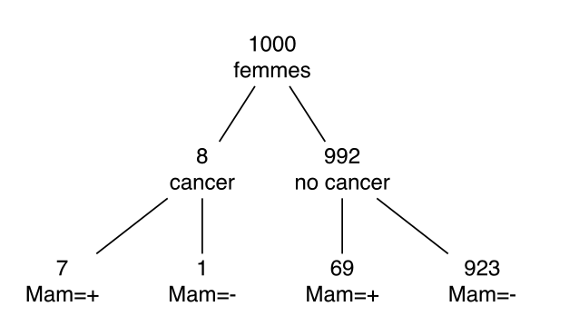

\[ p(Cancer=+|Mam=+)=\frac{7}{7+69}=\frac{7}{76}\approx.09 \]

### Diagnostique médical, théorème de Bayes

\[ \color{purple}{p(\theta \vert x)} = \dfrac{\color{orangered}{p(x\vert \theta)} \color{steelblue}{p(\theta)}}{\color{green}{p(x)}} \]

\( \color{steelblue}{p(\theta)} \) la probabilité *a priori* de \( \theta \): tout ce qu'on sait de \( \theta \) avant d'observer les données. Par exemple: \( p(Cancer=+)=.008 \) et \( p(Cancer=-)=.992 \).

```r
prior <- c(0.008, 0.992)
```

### Diagnostique médical, théorème de Bayes

\[ \color{purple}{p(\theta \vert x)} = \dfrac{\color{orangered}{p(x\vert \theta)} \color{steelblue}{p(\theta)}}{\color{green}{p(x)}} \]

\( \color{orangered}{p(x\vert \theta)} \) probabilité conditionnelle des données (\( x \)) sachant le paramètre (\( \theta \)), qu'on appelle aussi la *likelihood* (*ou fonction de vraissemblance*) du paramètre (\( \theta \)).

```r
like <- rbind(c(0.9, 0.1), c(0.07, 0.93) ) %>% data.frame
colnames(like) <- c("Mam+", "Mam-")
rownames(like) <- c("Cancer+", "Cancer-")
like
```

```
        Mam+ Mam-
Cancer+ 0.90 0.10
Cancer- 0.07 0.93
```

### Diagnostique médical, théorème de Bayes

\[ \color{purple}{p(\theta \vert x)} = \dfrac{\color{orangered}{p(x\vert \theta)} \color{steelblue}{p(\theta)}}{\color{green}{p(x)}} \]

\( p(x) \) la probabilité marginale de \( x \) (sur \( \theta \)). Sert à normaliser la distribution.

\[ \color{green}{p(x)=\sum\limits_{\theta}p(x|\theta)p(\theta)} \]

```r
(marginal <- sum(like$"Mam+" * prior) )
```

```
[1] 0.07664
```

### Diagnostique médical, théorème de Bayes

\[ \color{purple}{p(\theta \vert x)} = \dfrac{\color{orangered}{p(x\vert \theta)} \color{steelblue}{p(\theta)}}{\color{green}{p(x)}} \]

\( \color{purple}{p(\theta \vert x)} \) la probabilité a posteriori de \( \theta \) sachant \( x \), c'est à dire ce qu'on sait de \( \theta \) après avoir pris connaissance de \( x \).

```r
(posterior <- (like$"Mam+" * prior ) / marginal )
```

```
[1] 0.09394572 0.90605428
```

### L'inférence bayésienne comme mise à jour probabiliste des connaissances

Avant de passer le mammogramme, la probabilité qu'une femme tirée au sort ait un cancer du sein était de \( p(Cancer)=.008 \) (*prior*). Après un résultat positif, cette probabilité est devenue \( p(Cancer|Mam+)=.09 \) (*posterior*). Ces probabilités sont des expressions de nos *connaissances*. Après un mammogramme positif, on pense toujours que c'est “très improbable” d'avoir un cancer, mais cette probabilité a considérablement évolué relativement à “avant le test”.

> A Bayesianly justifiable analysis is one that *treats known values as observed values of random variables, treats unknown values as unobserved random variables, and calculates the conditional distribution of unknowns given knowns and model specifications using Bayes’ theorem*. – Rubin (1984)

### Monty Hall

[video not shown]

### Monty Hall

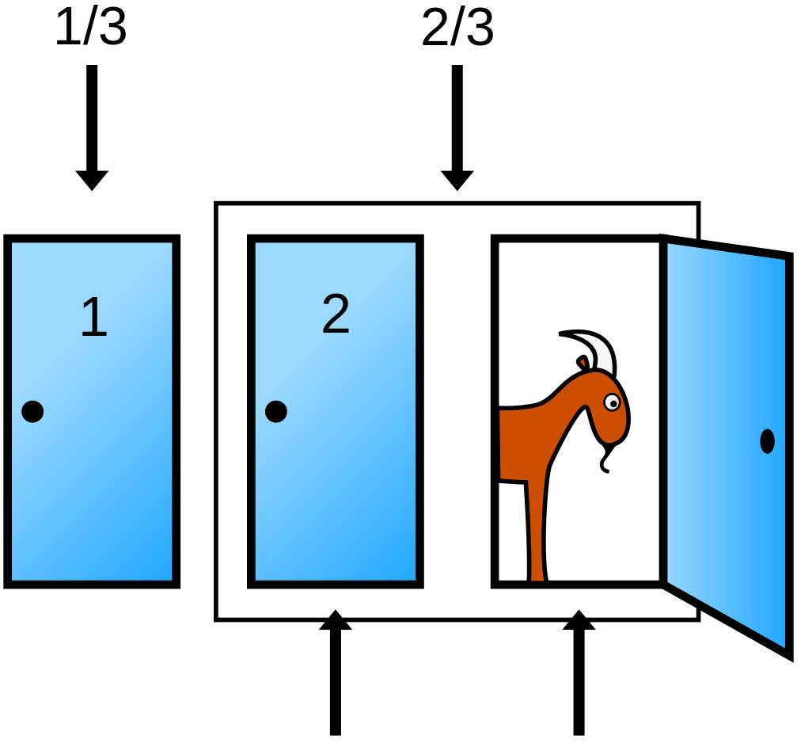

Que-feriez-vous (intuitivement) ? Analysez ensuite la situation en utilisant le théorème de Bayes.

### Monty Hall

Il s'agit d'un problème de probabilités conditionnelles… Définissons les événements suivants:

P1: l'animateur ouvre la porte 1  
P2: l'animateur ouvre la porte 2  
P3: l'animateur ouvre la porte 3

V1: la voiture se trouve derrière la porte 1  
V2: la voiture se trouve derrière la porte 2  
V3: la voiture se trouve derrière la porte 3

Si on a choisi la porte n°1 et que l'animateur a choisi la porte n°3 (*et qu'il sait où se trouve la voiture*), il s'ensuit que:

\( p(P3|V1)=\dfrac{1}{2} \), \( p(P3|V2)=1 \), \( p(P3|V3)=0 \)

### Monty Hall

On sait que \( p(V3|P3)=0 \), on veut connaître \( p(V1|P3) \) et \( p(V2|P3) \) afin de pouvoir choisir. Résolution par le théorème de Bayes.

\( p(V1|P3)=\dfrac{p(P3|V1) \times p(V1)}{p(P3)}=\dfrac{\dfrac{1}{2} \times \dfrac{1}{3}}{\dfrac{1}{2}}=\dfrac{1}{3} \)

\( p(V2|P3)=\dfrac{p(P3|V2) \times p(V2)}{p(P3)}=\dfrac{1 \times \dfrac{1}{3}}{\dfrac{1}{2}}=\dfrac{2}{3} \)

### Monty Hall

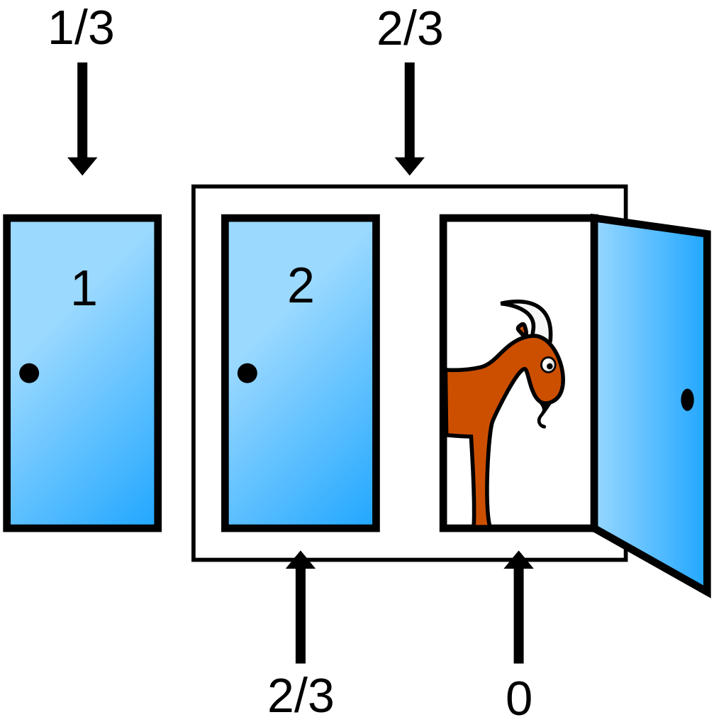

### Morale

Nos intuitions probabilistes sont, dans la grande majorité des cas, très mauvaises. Au lieu de compter sur elles, il est plus sage de se reposer sur des règles logiques (*modus ponens* et *modus tollens*) et probabilistes simples (règle du produit, règle de la somme, théorème de Bayes), nous assurant de réaliser l'inférence logique la plus juste.

Autrement dit, “Don't be clever” (McElreath, 2015).

### Further resources

Books

- McElreath, R. (2015). *Statistical Rethinking: A Bayesian Course with Examples in R and Stan*. CRC Press.
- Kruschke, J. K. (2015). *Doing Bayesian Data Analysis, Second Edition: A Tutorial with R, JAGS, and Stan*. Academic Press / Elsevier.
- Gelman, A., Carlin, J. B., Stern, H. S., Dunson, D. B., Vehtari, A., Rubin, D. B. (2013). *Bayesian Data Analysis, third edition*. London: CRC Press.
- Noël, Y. (2013). *Psychologie statistique avec R*. Springer.

Slides are available here: https://github.com/lnalborczyk

### References

Carnap, R. (1950). *Logical foundations of probability*. Chicago, IL, US: University of Chicago Press.

Jaynes, E. (1986). Bayesian Methods: General Background. In J. Justice (Author), Maximum Entropy and Bayesian Methods in Applied Statistics Proceedings of the Fourth Maximum Entropy Workshop University of Calgary, 1984 (pp. 1-25). Cambridge: Cambridge University Press.

Keynes, J. M. (1921). *Treatise on Probability*. London: Macmillan & Co.

Kolmogorov, A. N. (1933). *Grundbegriffe der Wahrscheinlichkeitrechnung, Ergebnisse Der Mathematik*. Translated as *Foundations of Probability*. New York: Chelsea Publishing Company, 1950.

Lakatos, I. (1970). Falsification and the methodology of scientific research programmes. In: Lakatos, Musgrave eds., pp. 91–195.

Lindley, D. (2000). The Philosophy of Statistics. Journal of the Royal Statistical Society. *Series D (The Statistician), 49*(3), 293-337.

### References

Meehl, P. (1990). Appraising and amending theories: The strategy of Lakatosian defense and two principles that warrant using it. *Psychological Inquiry, 1*, 108-141, 173-180.

Pollard, P., & Richardson, J. T. E. (1987). On the probability of making type I errors. *Psychological Bulletin, 102*(1), 159-163.

Rouder, J. N., Morey, R. D., & Wagenmakers, E.-J. (2016). The Interplay between Subjectivity, Statistical Practice, and Psychological Science. *Collabra, 2*(1), 1-12.

Rouder, J. N., Morey, R. D., Verhagen, J., Province, J. M., Wagenmakers, E. J. (2016). Is There a Free Lunch in Inference? *Topics in Cognitive Science, 8*, 520-47.